# Working with Phylogenies and Calculating Phylogenetic Diversity

We are going to read in a phylogeny (.tre file), learn how to manipulate that phylogeny in R, and calculate some basic phylogenetic diversity indices.

The phylogeny we are going to work with contains species from >80 alpine plant communities in North and South America, Europe, Asia and New Zealand,

```r
setwd('U:/LOCKED/phylo_data/')
library(ape)
gammaTree=read.tree("bladj_dichotomous.tre")
gammaTree#this is the summary info provide for a phylo object in ape
```

```
##
## Phylogenetic tree with 1068 tips and 1067 internal nodes.
##
## Tip labels:
##  Azorella_licopodioidis, Azorella_coespitosa, Azorella_aretioides, Azorella_trifurcata, Azorella_fuegiana, Azorella_pedunculata, ...
## Node labels:
##  monocotneudicot, eudicot, coreeudicot, , , asterid, ...
##
## Rooted; includes branch lengths.
```

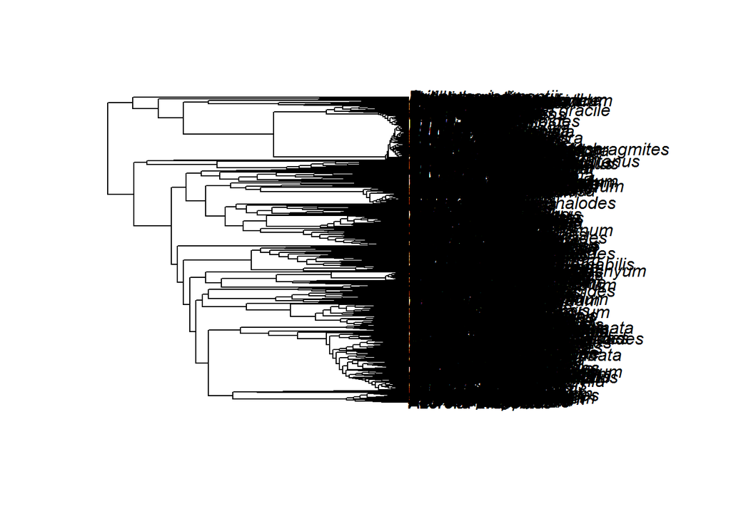

```r
plot(gammaTree)
```

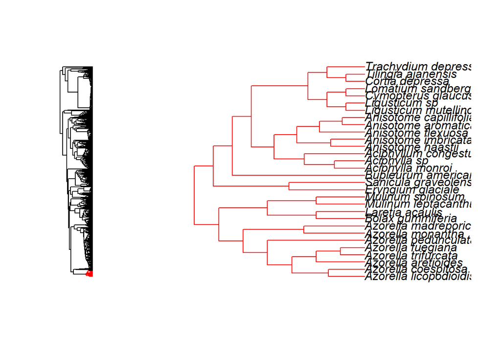

```r
zoom(gammaTree,1:30)
```

There are many more tools for manipulating and plotting phylogenies in R. Check out the ape package for more info.

We are just going to focus on the phylogenetic composition of a single commmunity from Slovakia out of the >80 upon which the phylogeny is based. The community dataset is split into two microhabitat types, cushion (other plants growing inside of cushion plants, in this case Silene acaulis) and open (bare ground).

Let’s read in the community dataset, then “prune” our tree to just those species that occur in this one dataset.

```r
commDat=read.csv('U:/LOCKED/phylo_data/commSlovakia.csv')
commDat[is.na(commDat)]=0#converting all of the empty cells, which are read in as NA, to zeros
library(picante)#a very useful package for community phylogenetic analysis
```

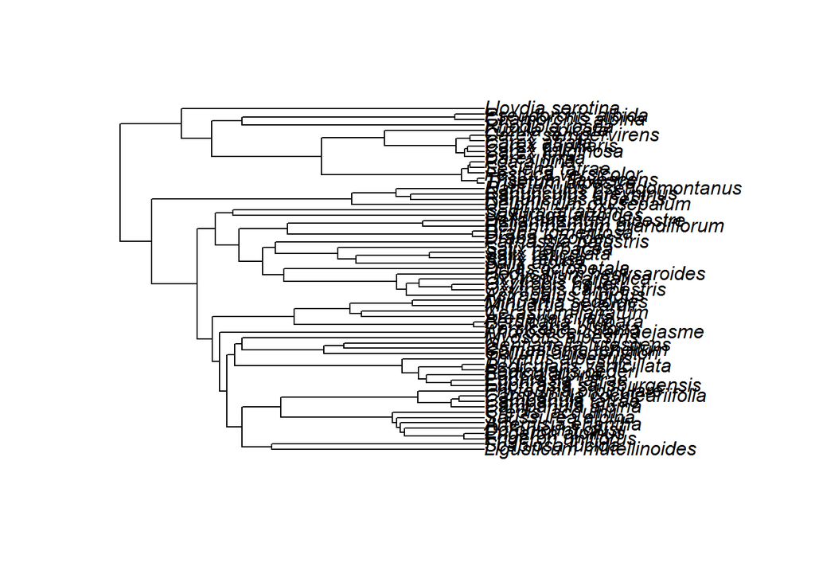

```r
alphaTree=prune.sample(commDat[,-c(1:2)],gammaTree)#this step prunes the tree by matching the tip labels of the master phylogeny to the column names in the dataset
plot(alphaTree)
```

Now let’s calculate phylogenetic diversity for the cushion and open communities serparately. PD is the sum of all branch lengths of a tree.

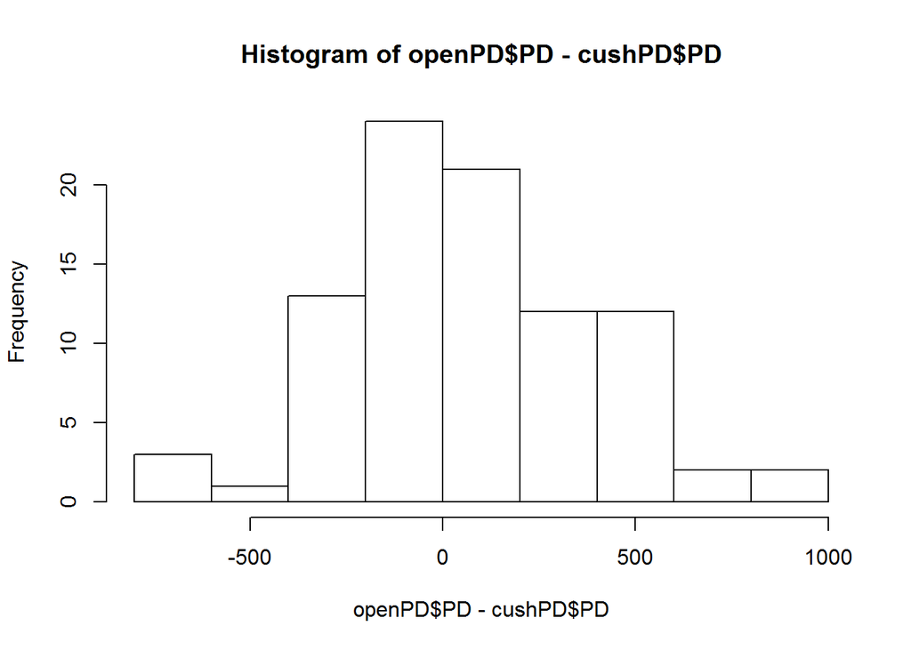

```r
cushPD=pd(commDat[commDat$cushion.open=='cushion',-c(1:2)],alphaTree)
openPD=pd(commDat[commDat$cushion.open=='open',-c(1:2)],alphaTree)
hist(openPD$PD-cushPD$PD)#we can see here that PD is typically greater in the open than in cushions
```